# PBMC: Effect of Sampling Time

Ramon Massoni-Badosa

10/20/2019

# 1 Introduction

The objective of this notebook is to test if the time required to cryopreserve a blood sample is a source of technical artifacts in single-cell RNA-seq (scRNA-seq) data. We will do so by computing and visualizing the ‘mixability’ of PBMC that were kept at varying times (0h, 2h, 8h, 24h, 48h) prior to freezing.

## 1.1 Package loading

```r
library(scater)
library(Seurat)
library(ggpubr)
library(purrr)
library(kBET)
library(tidyverse)
```

## 1.2 Source script with function definitions

```r
source("bin/utils.R")
```

## 1.3 Load data

Our data consists of a list of two (male/female) demultiplexed, filtered, normalized and annotated Seurat objects. Also, we have a merged dataset that combines both male and female:

```r
pbmc_l <- readRDS("results/R_objects/10X_pbmc_Seurat_donors_list_clustered.RDS")
pbmc_l
```

```
## $male
## An object of class Seurat
## 9803 features across 7471 samples within 1 assay
## Active assay: RNA (9803 features)
##  3 dimensional reductions calculated: pca, tsne, umap
##
## $female
## An object of class Seurat
## 9803 features across 2893 samples within 1 assay
## Active assay: RNA (9803 features)
##  3 dimensional reductions calculated: pca, tsne, umap
```

```r
pbmc <- readRDS("results/R_objects/10X_pbmc_Seurat_clustered.RDS")
pbmc <- subset(pbmc, subset = condition %in% c("0h", "2h", "8h", "24h_RT", "48h_RT"))
```

# 2 Visualize mixability

Let us visualize the mixability of the PBMCs with different sampling times. Our hypothesis is that, if this variable introduces artifacts, cells will cluster by time.

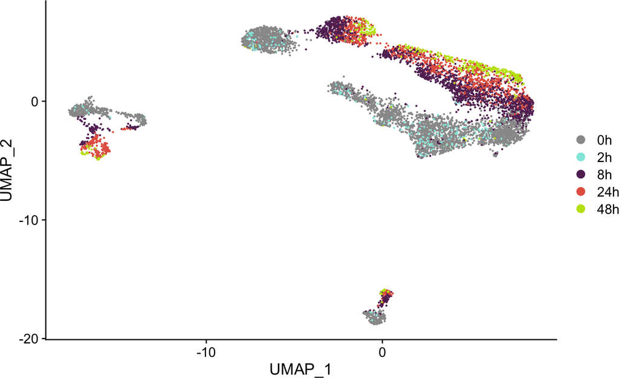

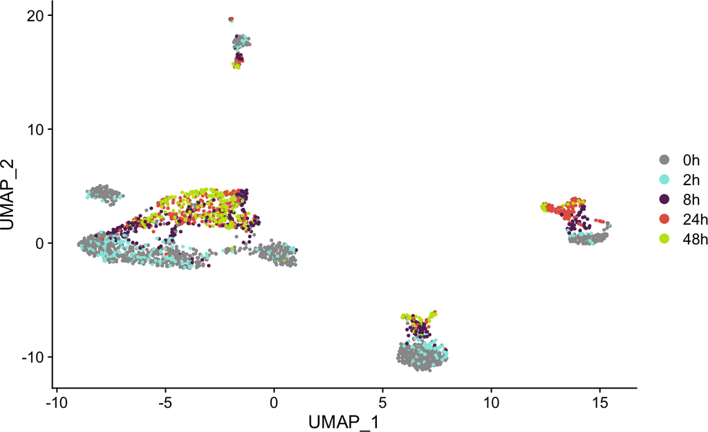

```r
# Recode variables
conds <- c("0h", "2h", "8h", "24h_RT", "48h_RT", "24h_4C", "48h_4C")
pbmc_l <- purrr::map(pbmc_l, function(s) {
  s$condition <- factor(s$condition, levels = conds)
  levels(s$condition) <- conds %>%
    str_remove("RT") %>%
    str_remove("_")
  s$temperature <- case_when(
    s$condition == "0h" ~ "fresh",
    s$condition %in% c("2h", "8h", "24h", "48h") ~ "RT",
    s$condition %in% c("24h4C", "48h4C") ~ "4ºC"
  )
  s <- subset(s, subset = temperature != "4ºC")
  s <- pre_process_seurat(s)
  s$time <- s$condition
  Idents(s) <- "time"
  s
})

# Visualize mixability (UMAP)
palette <- c("#999999", "#92e8df", "#632c63", "#e4624e", "#c0e212")
umaps_time <- purrr::map(
  pbmc_l,
  DimPlot,
  reduction = "umap",
  cols = palette
)
umaps_time
```

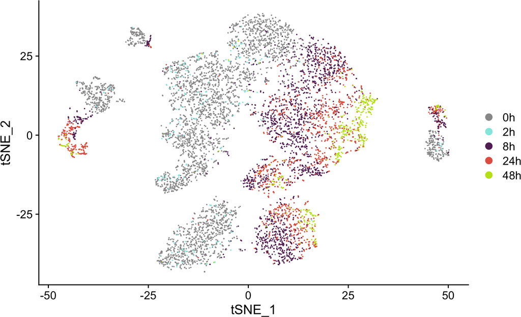

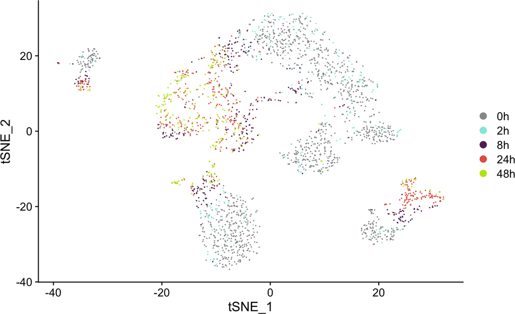

```r
# Visualize mixability (TSNE)
tsnes_time <- purrr::map(
  pbmc_l,
  DimPlot,
  reduction = "tsne",
  pt.size = 0.025,
  cols = palette
)
tsnes_time
```

```r
# saveRDS(tsnes_time, "results/R_objects/ggplots/tsne_time_points_PBMC_Seuratv3.rds")
# saveRDS(pbmc_l$male, "results/R_objects/pbmc_Seurat_male.rds")
```

As we can see, within each cell type cells cluster by time.

# 3 Principal Component Analysis (PCA)

Let us asses if, for each cell type, time is the major source of variance in the dataset:

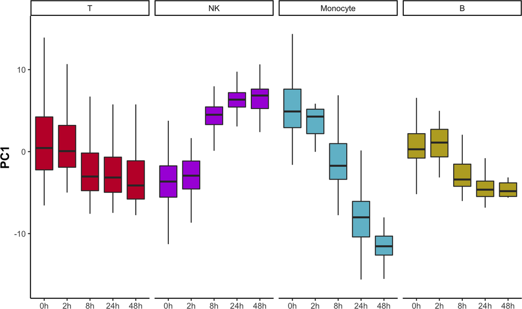

```r
pbmc_types <- SplitObject(pbmc, split.by = "cell_type")
pbmc_types <- purrr::map(pbmc_types, pre_process_seurat)
pbmc_types_pca <- purrr::map(pbmc_types, function(seurat) {
  df <- as.data.frame(seurat@reductions$pca@cell.embeddings[, 1:2])
  df$time <- seurat$condition
  df$time <- str_remove(df$time, "_RT")
  df$time <- factor(df$time, levels = c("0h", "2h", "8h", "24h", "48h"))
  df
})
pbmc_types_pca <- bind_rows(pbmc_types_pca, .id = "cell_type")
pbmc_types_pca$cell_type <- factor(
  pbmc_types_pca$cell_type,
  levels = c("T", "NK", "Monocyte", "B")
)
palette2 <- c("#c20a35", "#aa2edc", "#71bdd0", "#bbaa2a")
pc1_vs_time <- pbmc_types_pca %>%
  filter(PC_1 < 15) %>%
  ggplot(aes(time, PC_1, fill = cell_type)) +
    geom_boxplot(outlier.shape = NA) +
    facet_grid(.~cell_type) +
    labs(x = "", y = "PC1") +
    scale_fill_manual("", values = palette2) +
    theme_classic() +
    theme(legend.position = "none",
          axis.title.y = element_text(size = 13, face = "bold"))
pc1_vs_time
```

```r
# saveRDS(pc1_vs_time, "results/R_objects/ggplots/pc1_time_Seuratv3_gg.rds")
```

Let us compute the percentage of variance explained by PC1 out of all the variance explained by the first 50 principal components:

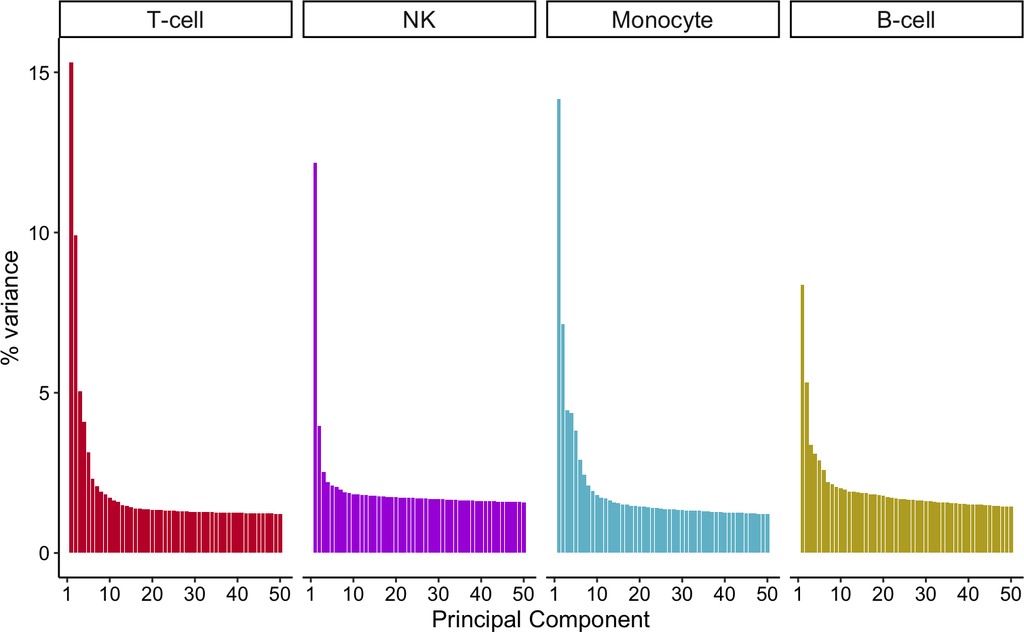

```r
pct_var_explained_dfs <- purrr::map(names(pbmc_types), function(type) {
  eigen_values <- pbmc_types[[type]]@reductions$pca@stdev ^ 2
  pct_var_explained <- eigen_values / sum(eigen_values) * 100
  pct_var_explained_df <- data.frame(
    pc = 1:length(pct_var_explained),
    pct_var_explained = pct_var_explained
  )
  pct_var_explained_df
})
names(pct_var_explained_dfs) <- names(pbmc_types)
pct_var_explained_df <- bind_rows(pct_var_explained_dfs, .id = "cell_type")
pct_var_explained_df$cell_type <- factor(
  pct_var_explained_df$cell_type,
  levels = levels(pbmc$cell_type)
)
levels(pct_var_explained_df$cell_type) <- c("T-cell", "NK", "Monocyte", "B-cell")
pct_var_gg <- pct_var_explained_df %>%
  ggplot(aes(pc, pct_var_explained, fill = cell_type)) +
    geom_col() +
    facet_grid(.~cell_type) +
    labs(x = "Principal Component", y = "% variance") +
    scale_x_continuous(labels = c(1, 10, 20, 30, 40, 50)) +
    scale_fill_manual("", values = palette2) +
    theme_classic() +
    theme(axis.title = element_text(size = 13),
          axis.text = element_text(size = 11, color = "black"),
          strip.text = element_text(size = 13),
          legend.position = "none")
pct_var_gg
```

```r
ggsave(
  filename = "results/plots/pct_variance_explained_pc1.pdf",
  plot = pct_var_gg,
  width = 12,
  height = 9,
  units = "cm"
)
# saveRDS(pct_var_gg, file = "results/R_objects/pct_variance_explained_pc1.rds")
```

# 4 Zoom-in into specific cell types

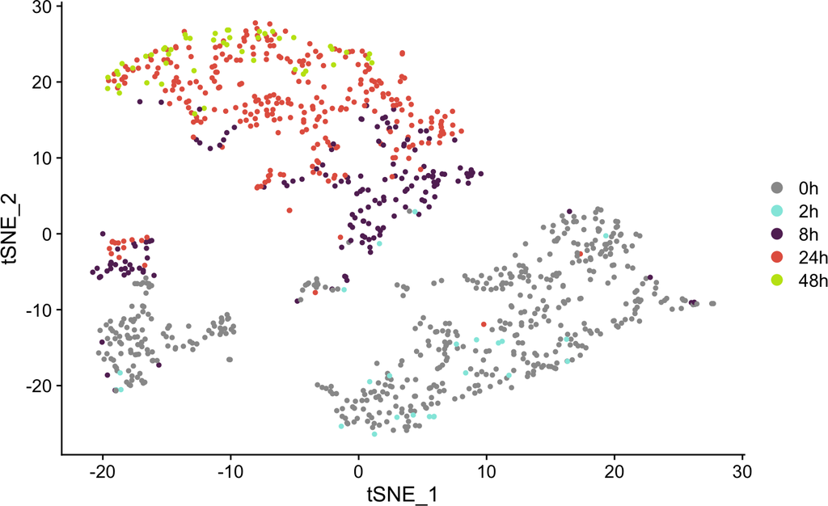

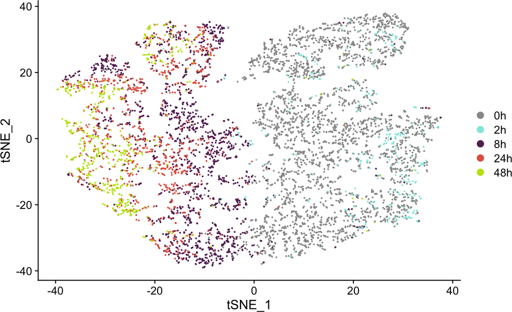

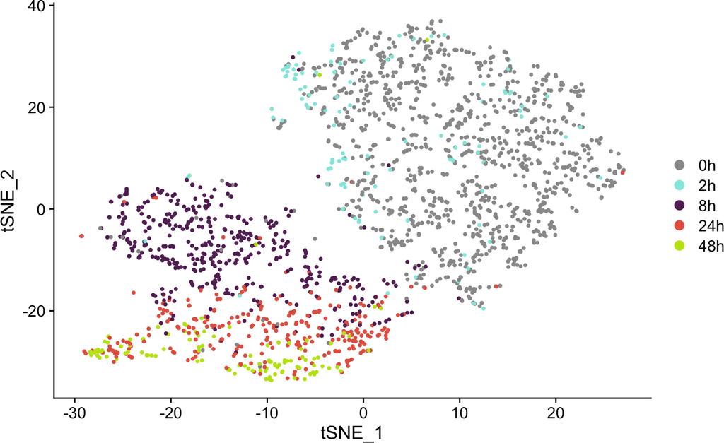

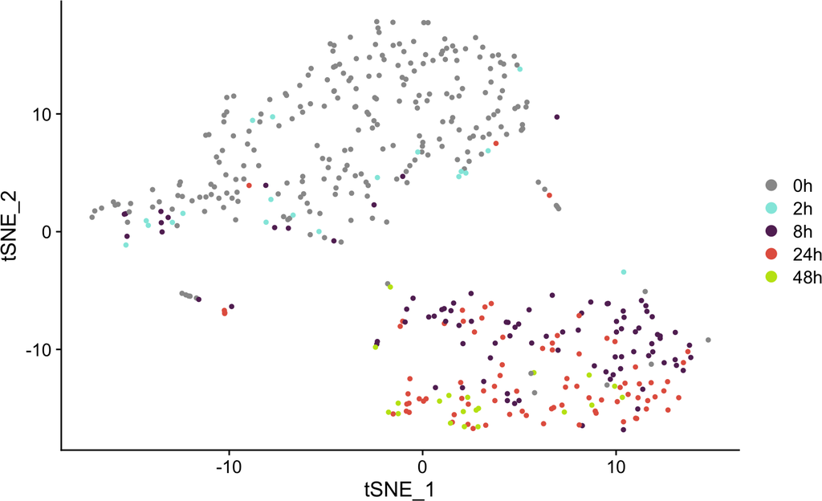

```r
pbmc_types <- purrr::map(pbmc_types, function(seurat) {
  seurat$time <- seurat$condition
  seurat$time <- str_remove(seurat$time, "_RT")
  seurat$time <- factor(seurat$time, c("0h", "2h", "8h", "24h", "48h"))
  Idents(seurat) <- "time"
  seurat
})
pbmc_types <- purrr::map(pbmc_types, RunTSNE)
tsne_types <- purrr::map(
  pbmc_types,
  DimPlot,
  reduction = "tsne",
  cols = c("#999999", "#92e8df", "#632c63", "#e4624e", "#c0e212")
)
tsne_types
```

```r
# saveRDS(tsne_types, "results/R_objects/ggplots/tsne_time_points_PBMC_cell_types_Seuratv3.rds")
```

# 5 kBET

To quantify the mixability between time-points, we will use the metric [kBET](https://www.nature.com/articles/s41592-018-0254-1). Intuitively, kBET compares the proportion of k-nearest neighbors that belong to each time-point with the global distribution. We say that a dataset is well-mixed if the local neighborhood approximates the global. We will compute the mixability of each time-point with our control (0h). The documentation of the package can be found [here](https://github.com/theislab/kBET).

```
## Initial neighbourhood size is set to 482.
## reducing dimensions with svd first...
## finding knns...done. Time:
##    user  system elapsed
##   1.008   0.022   1.092
## KNN input is a list, extracting nearest neighbour index.
```

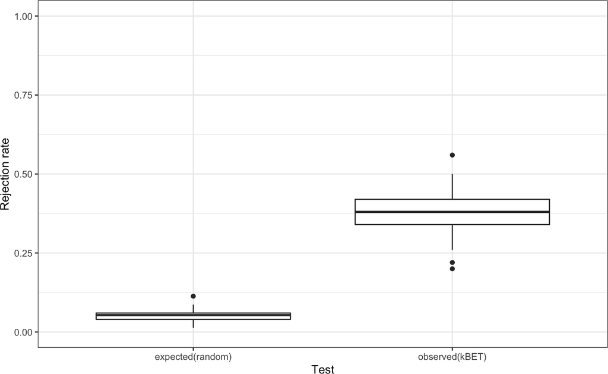

```
## Initial neighbourhood size is set to 685.
## reducing dimensions with svd first...
## finding knns...done. Time:
##    user  system elapsed
##   2.591   0.034   2.659
## KNN input is a list, extracting nearest neighbour index.
```

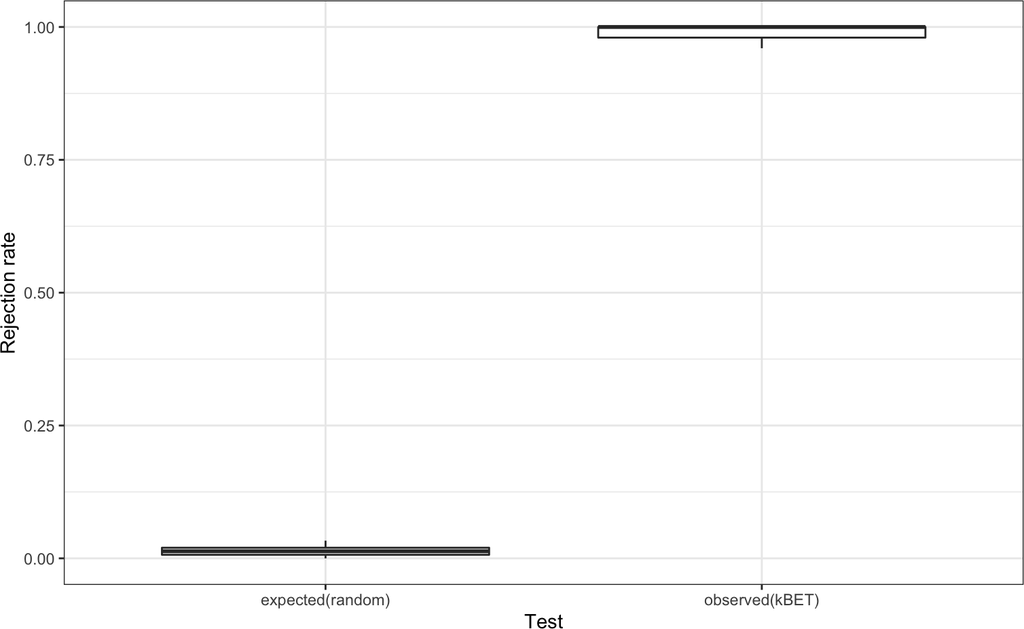

```
## Initial neighbourhood size is set to 608.
## reducing dimensions with svd first...
## finding knns...done. Time:
##    user  system elapsed
##   1.906   0.031   1.977
## KNN input is a list, extracting nearest neighbour index.
```

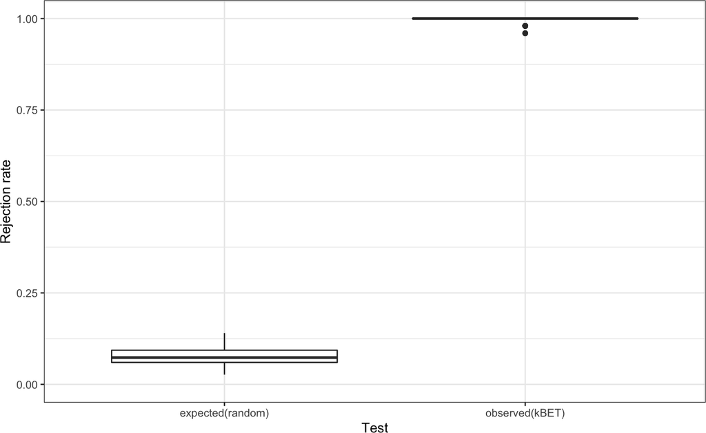

```
## Initial neighbourhood size is set to 509.
## reducing dimensions with svd first...
## finding knns...done. Time:
##    user  system elapsed
##   1.132   0.014   1.159
## KNN input is a list, extracting nearest neighbour index.
```

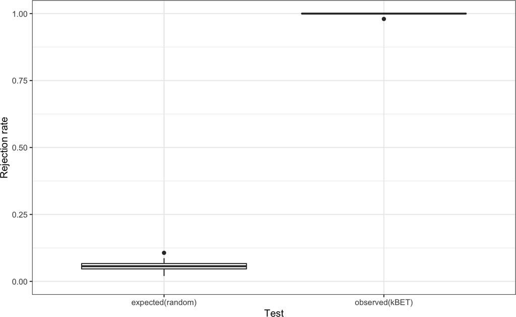

```
## Initial neighbourhood size is set to 190.
## reducing dimensions with svd first...
## finding knns...done. Time:
##    user  system elapsed
##   0.091   0.002   0.093
## KNN input is a list, extracting nearest neighbour index.
```

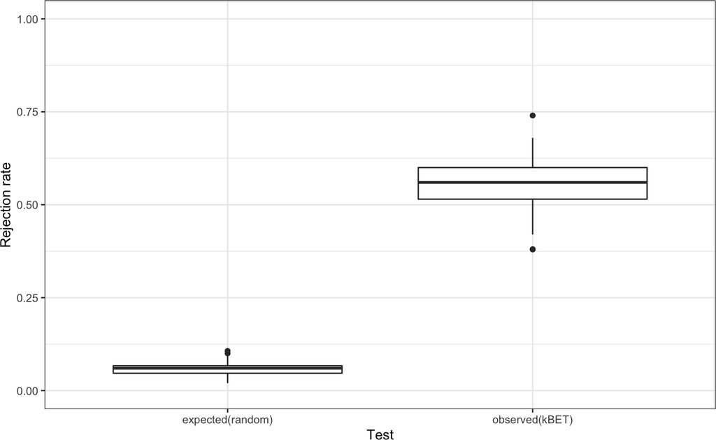

```
## Initial neighbourhood size is set to 197.
## reducing dimensions with svd first...
## finding knns...done. Time:
##    user  system elapsed
##   0.095   0.002   0.098
## KNN input is a list, extracting nearest neighbour index.
```

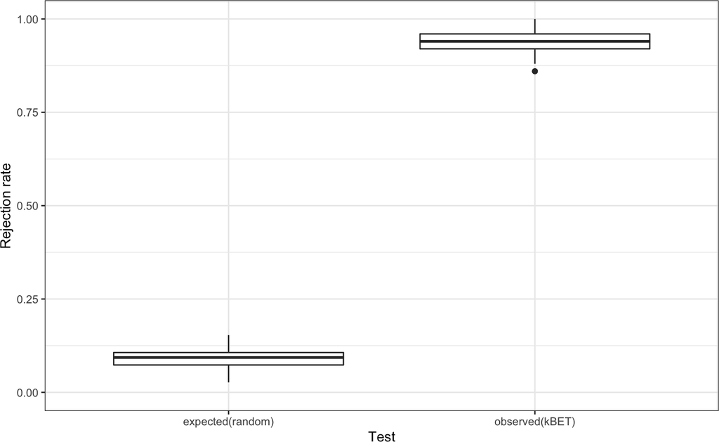

```
## Initial neighbourhood size is set to 208.
## reducing dimensions with svd first...
## finding knns...done. Time:
##    user  system elapsed
##   0.111   0.002   0.114
## KNN input is a list, extracting nearest neighbour index.
```

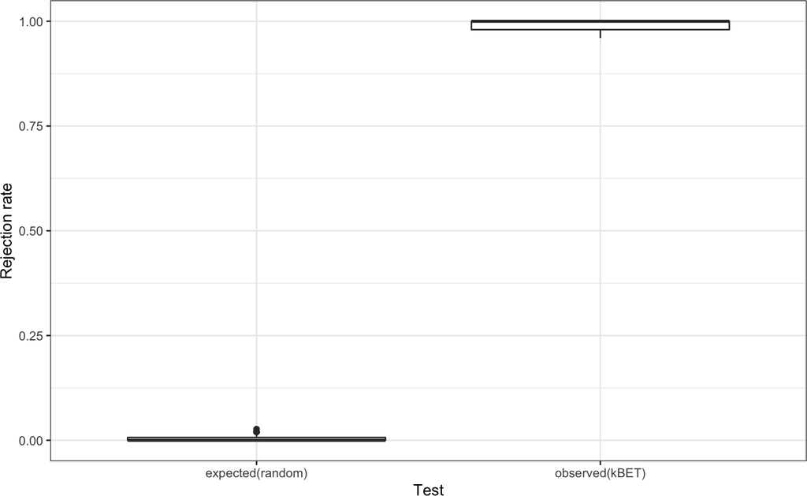

```
## Initial neighbourhood size is set to 191.
## reducing dimensions with svd first...
## finding knns...done. Time:
##    user  system elapsed
##   0.089   0.001   0.091
## KNN input is a list, extracting nearest neighbour index.
```

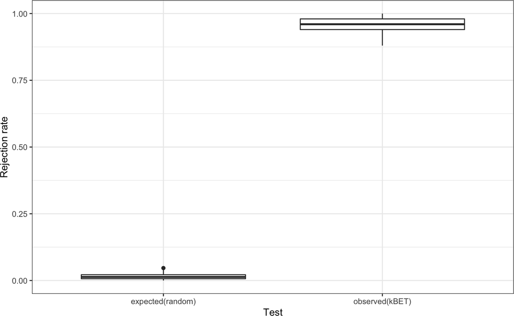

```r
# Calculate rejection rates
times <- c("2h", "8h", "24h", "48h")
rejection_rate_df <- purrr::map(pbmc_l, function(seurat) {
  Idents(seurat) <- "time"
  rejection_rate_dbl <- purrr::map_dbl(times, function(t) {
    seurat_sub <- subset(seurat, idents = c("0h", t))
    seurat_sub$time <- seurat_sub$condition
    seurat_sub$time <- str_remove(seurat_sub$time, "_RT")
    seurat_sub$is_biased <- ifelse(seurat_sub$time == "0h", FALSE, TRUE)
    Idents(seurat_sub) <- "time"
    mat <- as.matrix(seurat_sub@reductions$umap@cell.embeddings)
    batch <- seurat_sub$is_biased
    batch_estimate <- kBET(mat, batch = batch, verbose = TRUE, heuristic = FALSE, testSize = 50)
    batch_results <- batch_estimate$results
    batch_results <- batch_results %>%
      mutate(cell_type = seurat_sub$cell_type,
             time = seurat_sub$time) %>%
      filter(tested == 1) %>%
      summarise(rejection_rate = 100 - mean(kBET.pvalue.test > 0.05) * 100)
    batch_results$rejection_rate
  })
  data.frame(time = times, rejection_rate = rejection_rate_dbl)
})
```

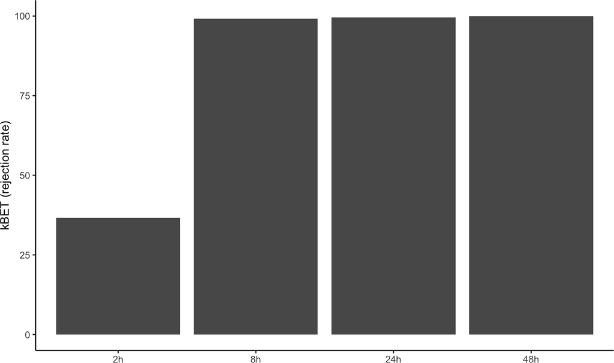

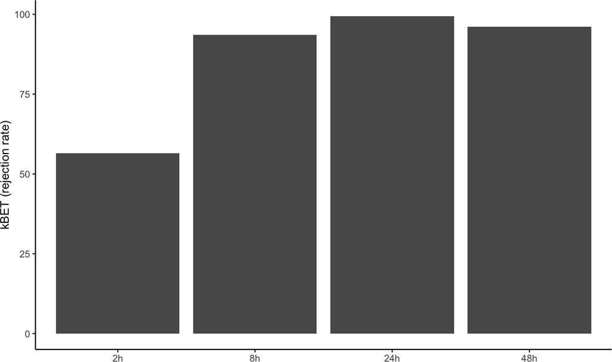

```r
# Plot rejection rates
rejection_rate_gg <- purrr::map(rejection_rate_df, function(df) {
  df %>%
    mutate(time = factor(time, levels = c("2h", "8h", "24h", "48h"))) %>%
    ggplot(aes(time, rejection_rate)) +
      geom_col() +
      labs(x = "", y = "kBET (rejection rate)") +
      theme_classic()
})
rejection_rate_gg
```

```r
# saveRDS(rejection_rate_gg, "results/R_objects/ggplots/barplot_rejection_rate_pbmc.rds")
```